DS 6030 | Fall 2024 | University of Virginia

# Homework #9: Feature Importance

Author

**Ashley Miller**

Published

November 14, 2024

# Required R packages and Directories

```r
dir_data = 'https://mdporter.github.io/teaching/data/' # data directory
library(tidyverse) # functions for data manipulation
library(tidymodels)
library(ranger)
```

# Problem 1: Permutation Feature Importance

Vanderbilt Biostats has collected data on Titanic survivors (https://hbiostat.org/data/). I have done some simple processing and split into a training and test sets.

- titanic_train.csv
- titanic_test.csv

We are going to use this data to investigate feature importance. Use `Class`, `Sex`, `Age`, `Fare`, `sibsp` (number of siblings or spouse on board), `parch` (number of parents or children on board), and `Joined` (city where passenger boarded) for the predictor variables (features) and `Survived` as the outcome variable.

## a. Load the titanic traning and testing data

**Solution**

```r
titanic_train <- read_csv(file.path(dir_data, "titanic_train.csv"))
titanic_test <- read_csv(file.path(dir_data, "titanic_test.csv"))
titanic_train <- titanic_train %>%
  mutate(Survived = as.factor(Survived))
titanic_test <- titanic_test %>%
  mutate(Survived = as.factor(Survived))
```

```r
# Count the number of missing values in each column
missing_values <- sapply(titanic_train, function(x) sum(is.na(x)))

# Create a dataframe to view the missing values count
missing_values_df <- data.frame(Feature = names(missing_values),
                                MissingValues = missing_values)

# Sort the missing values in descending order
missing_values_df <- missing_values_df[order(missing_values_df$MissingValues, decreasing = TRUE), ]

print(missing_values_df)
```

```
              Feature MissingValues
Job               Job           970
Occupation Occupation           481
Fare             Fare             3
Age               Age             2
Name_ID       Name_ID             0
Name             Name             0
Sex               Sex             0
Class           Class             0
Ticket         Ticket             0
Joined         Joined             0
sibsp           sibsp             0
parch           parch             0
Survived     Survived             0
```

## b. Method 1: Built-in importance scores

Fit a tree ensemble model (e.g., Random Forest, boosted tree) on the training data. You are free to use any method to select the tuning parameters.

Report the built-in feature importance scores and produce a barplot with feature on the x-axis and importance on the y-axis.

**Solution**

```r
head(titanic_train)
```

```
# A tibble: 6 × 13
  Name_ID Name      Sex     Age Class Ticket Joined Occupation Job    Fare sibsp
    <dbl> <chr>     <chr> <dbl> <dbl> <chr>  <chr>  <chr>      <chr> <dbl> <dbl>
1      36 ALLISON,… fema…     2     1 113781 South… <NA>       <NA>  152.      1
2      37 ALLISON,… male     30     1 113781 South… Businessm… <NA>  152.      1
3      38 ALLISON,… fema…    25     1 113781 South… <NA>       <NA>  152.      1
4      71 ARTAGAVE… male     71     1 17609  Cherb… Businessm… <NA>   49.5     0
5      87 ASTOR, C… male     47     1 17757  Cherb… Property … <NA>  248.      1
6     146 BAUMANN,… male     60     1 17318  Cherb… Businessm… <NA>   25.9     0
# ℹ 2 more variables: parch <dbl>, Survived <fct>
```

```r
summary(titanic_train)
```

```
    Name_ID         Name               Sex                 Age
 Min.   :   1   Length:1008        Length:1008        Min.   : 0.0
 1st Qu.: 538   Class :character   Class :character   1st Qu.:21.0
 Median :1088   Mode  :character   Mode  :character   Median :28.0
 Mean   :1078                                         Mean   :29.6
 3rd Qu.:1588                                         3rd Qu.:39.0
 Max.   :2208                                         Max.   :71.0
                                                      NA's   :2
     Class         Ticket             Joined           Occupation
 Min.   :1.00   Length:1008        Length:1008        Length:1008
 1st Qu.:2.00   Class :character   Class :character   Class :character
 Median :3.00   Mode  :character   Mode  :character   Mode  :character
 Mean   :2.29
 3rd Qu.:3.00
 Max.   :3.00

     Job                 Fare         sibsp          parch      Survived
 Length:1008        Min.   :  0   Min.   :0.00   Min.   :0.00   0:623
 Class :character   1st Qu.:  8   1st Qu.:0.00   1st Qu.:0.00   1:385
 Mode  :character   Median : 14   Median :0.00   Median :0.00
                    Mean   : 34   Mean   :0.49   Mean   :0.39
                    3rd Qu.: 31   3rd Qu.:1.00   3rd Qu.:0.00
                    Max.   :512   Max.   :8.00   Max.   :9.00
                    NA's   :3
```

```r
titanic_recipe <- recipe(Survived ~ Class + Sex + Age + Fare + sibsp + parch + Joined, data = titanic_train) %>%
  step_impute_median(Age, Fare) %>%
  step_dummy(all_nominal_predictors()) %>%
  step_normalize(all_numeric_predictors())

ranger_model <- rand_forest(mtry = tune(), trees = tune()) %>%
  set_engine("ranger", importance = "permutation") %>%
  set_mode("classification")

titanic_workflow <- workflow() %>%
  add_recipe(titanic_recipe) %>%
  add_model(ranger_model)

tune_grid <- grid_regular(mtry(range = c(1, 5)),
                          trees(range = c(500, 1500)),
                          levels = 5)

set.seed(666)
cv_folds <- vfold_cv(titanic_train, v = 5)

tuned_results <- titanic_workflow %>%
  tune_grid(resamples = cv_folds, grid = tune_grid,
             control = control_grid(save_pred = TRUE))


best_results <- tuned_results %>% select_best(metric = "accuracy")

final_workflow <- titanic_workflow %>% finalize_workflow(best_results)

final_fit <- final_workflow %>% fit(data = titanic_train)
```

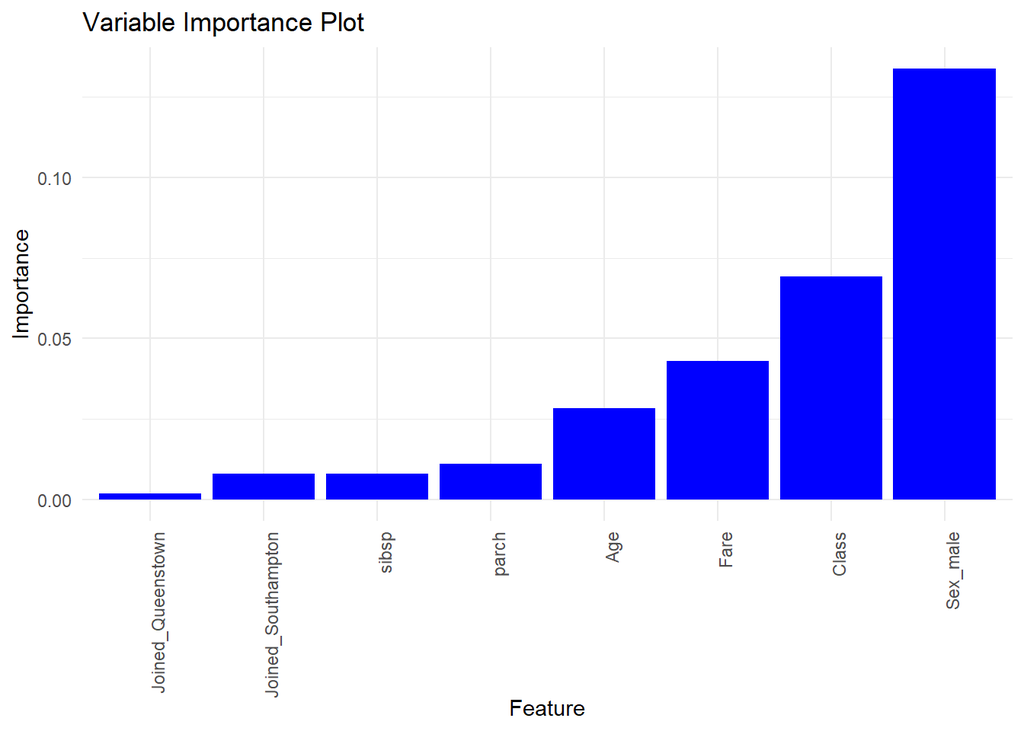

```r
library(vip)
feature_importance <- vi(final_fit)

vi_df <- as.data.frame(feature_importance)


ggplot(vi_df, aes(x = reorder(Variable, Importance), y = Importance)) +
  geom_bar(stat = "identity", fill = "blue") +
  theme_minimal() +
  labs(title = "Variable Importance Plot",
       x = "Feature",
       y = "Importance") +
  theme(axis.text.x = element_text(angle = 90, hjust = 1))
```

## c. Performance

Report the performance of the model fit from (a.) on the test data. Use the log-loss (where $M$ is the size of the test data):
$$\text{log-loss}(\hat{p}) = - \frac{1}{M} \sum_{i=1}^m [y_i \log \, \hat{p}_i + (1 - y_i) \log \, (1 - \hat{p}_i)]$$

**Solution**

```r
library(yardstick)

titanic_predictions <- final_fit %>%
  predict(new_data = titanic_test, type = "prob") %>%
  bind_cols(titanic_test)

log_loss_result <- titanic_predictions %>%
  mn_log_loss(truth = Survived, .pred_1)

actual <- as.numeric(titanic_predictions$Survived)
predicted <- titanic_predictions$.pred_1


log_loss_manual <- function(actual, predicted,epsilon = 1e-15) {
  predicted <- pmax(pmin(predicted, 1 - epsilon), epsilon)
  M <- length(actual)
  log_loss <- - (1 / M) * sum(actual * log(predicted) + (1 - actual)*log(1-predicted))
}
log_loss_result_man <- log_loss_manual(actual, predicted)

print(log_loss_result)
```

```
# A tibble: 1 × 3
  .metric     .estimator .estimate
  <chr>       <chr>          <dbl>
1 mn_log_loss binary          1.88
```

## d. Method 2: Permute *after* fitting

Use the fitted model from question (a.) to perform permutation feature importance. Shuffle/permute each variable individually on the *test set* before making predictions. Record the loss. Repeat $M=10$ times and produce a boxplot of the change in loss (change from reported loss from part b.).

**Solution**

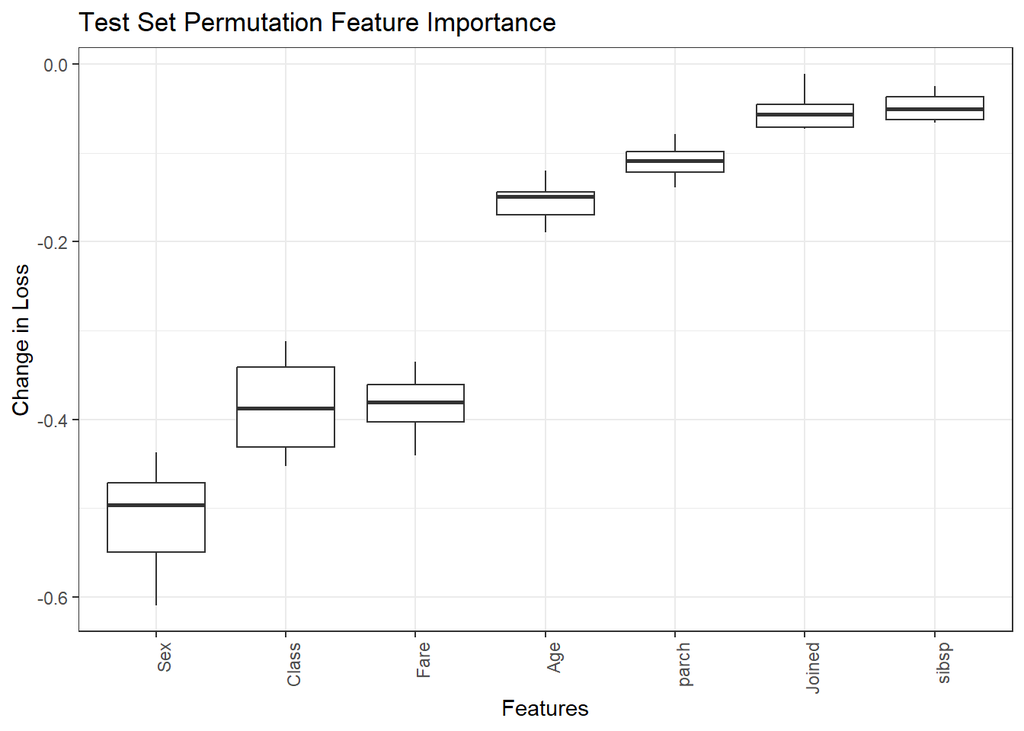

```r
baseline_preds <- predict(final_fit, titanic_test, type = "prob") %>% bind_cols(titanic_test)
baseline_loss <- baseline_preds %>%
  mn_log_loss(truth = Survived, .pred_1) %>%
  pull(.estimate)


set.seed(666)
M <- 10
specified_predictors <- c("Class", "Sex", "Age", "Fare", "sibsp", "parch", "Joined")
feature_importance <- list()

for (col in specified_predictors) {
  losses <- numeric(M)

  for (i in 1:M) {
    permuted_test <- titanic_test %>%
      mutate(!!col := sample(!!sym(col)))

    permuted_preds <- predict(final_fit, permuted_test, type = "prob") %>%
      bind_cols(permuted_test)

    permuted_loss <- permuted_preds %>%
      mn_log_loss(truth = Survived, .pred_1) %>%
      pull(.estimate)

    losses[i] <- permuted_loss - baseline_loss
  }

  feature_importance[[col]] <- losses
}

vi_df <- do.call(rbind, lapply(names(feature_importance), function(x) {
  data.frame(Variable = x, ChangeInLoss = feature_importance[[x]])
})) %>%
  as_tibble()


ggplot(vi_df, aes(x = reorder(Variable, ChangeInLoss), y = ChangeInLoss)) +
  geom_boxplot() +
  labs(title = "Test Set Permutation Feature Importance",
       x = "Features",
       y = "Change in Loss") +
  theme(axis.text.x = element_text(angle = 90, hjust = 1))
```

## e. Method 3: Permute *before* fitting

For this approach, shuffle/permute the *training data* and re-fit the ensemble model. Evaluate the predictions on the (unaltered) test data. Repeat $M=10$ times (for each predictor variable) and produce a boxplot of the change in loss.

**Solution**

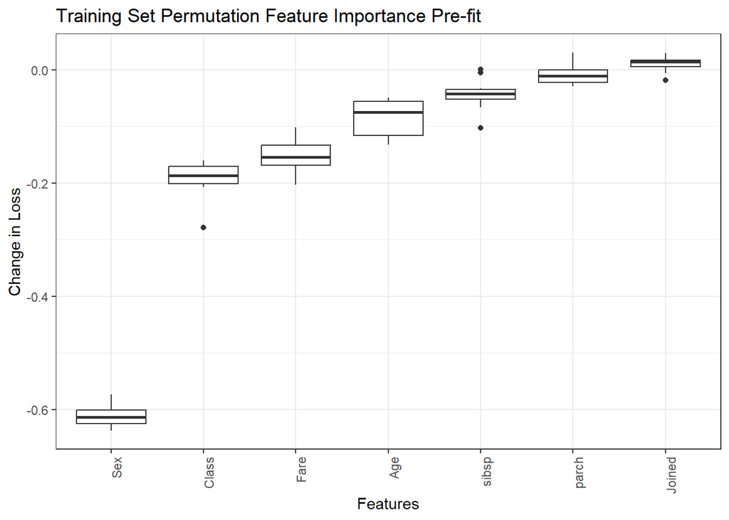

```r
permute_fit <- function(train_data, test_data, final_workflow, col, M = 10) {
  losses <- numeric(M)

  for (i in 1:M) {
    permuted_train <- train_data %>%
      mutate(!!col := sample(!!sym(col)))

    permuted_fit <- final_workflow %>% fit(data = permuted_train)


    permuted_preds <- predict(permuted_fit, test_data, type = "prob") %>%
      bind_cols(test_data)

    permuted_loss <- permuted_preds %>%
      mn_log_loss(truth = Survived, .pred_1) %>%
      pull(.estimate)

    losses[i] <- permuted_loss
  }

  return(losses)
}

final_fit <- final_workflow %>% fit(data = titanic_train)
baseline_preds <- predict(final_fit, titanic_test, type = "prob") %>% bind_cols(titanic_test)
baseline_loss <- baseline_preds %>%
  mn_log_loss(truth = Survived, .pred_1) %>%
  pull(.estimate)

set.seed(666)
specified_predictors <- c("Class", "Sex", "Age", "Fare", "sibsp", "parch", "Joined")
feature_importance <- list()

for (col in specified_predictors) {
  losses <- permute_fit(titanic_train, titanic_test, final_workflow, col, M = 10)
  feature_importance[[col]] <- losses - baseline_loss
}

vi_df <- do.call(rbind, lapply(names(feature_importance), function(x) {
  data.frame(Variable = x, ChangeInLoss = feature_importance[[x]])
})) %>%
  as_tibble()

ggplot(vi_df, aes(x = reorder(Variable, ChangeInLoss), y = ChangeInLoss)) +
  geom_boxplot() +
  labs(title = "Training Set Permutation Feature Importance Pre-fit",
       x = "Features",
       y = "Change in Loss") +
  theme(axis.text.x = element_text(angle = 90, hjust = 1))
```

## f. Understanding

Describe the benefits of each of the three approaches to measure feature importance.

**Solution**

The first method with built in scores is useful when the package has the functionality natively as it is efficient and is interpretable since it is tailored to the model. It doesn’t, however, allow us to prescribe the metric as we are limited to the choices made by the package creator, and also doesn’t work with models that don’t build in importance scores. It also gives us a point estimate as opposed to a set of values. The second method is useful because it is generalizable to any model, and tells us more about how a certain predictor affects model performance. It also isn’t computationally intensive like the last method. The third method tells us more about how each predictor affects the model’s ability to learn from the training data.

# Problem 2: Effects of correlated predictors

This problem will illustrate what happens to the importance scores when there are highly associated predictors.

## a. Create an almost duplicate feature

Create a new feature `Sex2` that is 95% the same as `Sex`. Do this by selecting 5% of training ($n=50$) and testing ($n=15$) data and flip the `Sex` value.

**Solution**

```r
set.seed(666)
n_train <- nrow(titanic_train)
n_flip_train <- ceiling(0.05 * n_train)

titanic_train <- titanic_train %>%
  mutate(Sex2 = Sex) %>%
  mutate(Sex2 = ifelse(row_number() %in% sample(n_train, n_flip_train),
                       ifelse(Sex == "male", "female", "male"),
                       Sex))

set.seed(666)
n_test <- nrow(titanic_test)
n_flip_test <- ceiling(0.05 * n_test)

titanic_test <- titanic_test %>%
  mutate(Sex2 = Sex) %>%
  mutate(Sex2 = ifelse(row_number() %in% sample(n_test, n_flip_test),
                       ifelse(Sex == "male", "female", "male"),
                       Sex))
```

## b. Method 1: Built-in importance

Fit the same model as in Problem 1b, but use the new data that includes `Sex2` (i.e., use both `Sex` and `Sex2` in the model). Calculate the built-in feature importance score and produce a barplot.

**Solution**

```r
titanic_recipe <- recipe(Survived ~ Class + Sex + Sex2 + Age + Fare + sibsp + parch + Joined, data = titanic_train) %>%
  step_impute_median(Age, Fare) %>%
  step_dummy(all_nominal_predictors()) %>%
  step_normalize(all_numeric_predictors())

ranger_model <- rand_forest(mtry = tune(), trees = tune()) %>%
  set_engine("ranger", importance = "permutation") %>%
  set_mode("classification")

titanic_workflow <- workflow() %>%
  add_recipe(titanic_recipe) %>%
  add_model(ranger_model)

tune_grid <- grid_regular(mtry(range = c(1, 5)),
                          trees(range = c(500, 1500)),
                          levels = 5)

set.seed(666)
cv_folds <- vfold_cv(titanic_train, v = 5)

tuned_results <- titanic_workflow %>%
  tune_grid(resamples = cv_folds, grid = tune_grid,
             control = control_grid(save_pred = TRUE))


best_results <- tuned_results %>% select_best(metric = "accuracy")

final_workflow <- titanic_workflow %>% finalize_workflow(best_results)

final_fit <- final_workflow %>% fit(data = titanic_train)
```

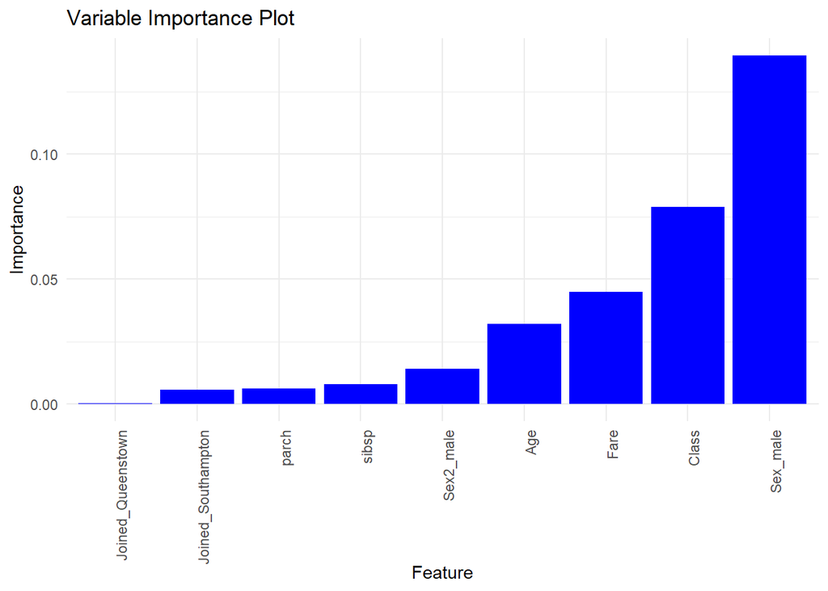

```r
feature_importance <- vi(final_fit)

vi_df <- as.data.frame(feature_importance)


ggplot(vi_df, aes(x = reorder(Variable, Importance), y = Importance)) +
  geom_bar(stat = "identity", fill = "blue") +
  theme_minimal() +
  labs(title = "Variable Importance Plot",
       x = "Feature",
       y = "Importance") +
  theme(axis.text.x = element_text(angle = 90, hjust = 1))
```

## c. Method 2: Permute *after* fitting

Redo Method 2 (problem 1d) on the new data/model and produce a boxplot of importance scores. The importance score is defined as the difference in loss.

**Solution**

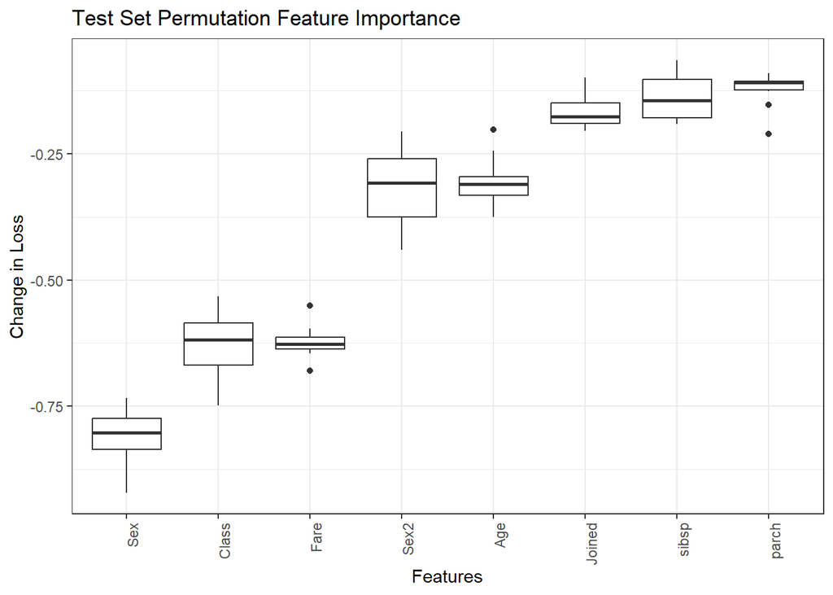

```r
baseline_preds <- predict(final_fit, titanic_test, type = "prob") %>% bind_cols(titanic_test)
baseline_loss <- baseline_preds %>%
  mn_log_loss(truth = Survived, .pred_1) %>%
  pull(.estimate)


set.seed(666)
M <- 10
specified_predictors <- c("Class", "Sex", "Sex2", "Age", "Fare", "sibsp", "parch", "Joined")
feature_importance <- list()

for (col in specified_predictors) {
  losses <- numeric(M)

  for (i in 1:M) {
    permuted_test <- titanic_test %>%
      mutate(!!col := sample(!!sym(col)))

    permuted_preds <- predict(final_fit, permuted_test, type = "prob") %>%
      bind_cols(permuted_test)

    permuted_loss <- permuted_preds %>%
      mn_log_loss(truth = Survived, .pred_1) %>%
      pull(.estimate)

    losses[i] <- permuted_loss - baseline_loss
  }

  feature_importance[[col]] <- losses
}

vi_df <- do.call(rbind, lapply(names(feature_importance), function(x) {
  data.frame(Variable = x, ChangeInLoss = feature_importance[[x]])
})) %>%
  as_tibble()


ggplot(vi_df, aes(x = reorder(Variable, ChangeInLoss), y = ChangeInLoss)) +
  geom_boxplot() +
  labs(title = "Test Set Permutation Feature Importance",
       x = "Features",
       y = "Change in Loss") +
  theme(axis.text.x = element_text(angle = 90, hjust = 1))
```

## d. Method 3: Permute *before* fitting

Redo Method 3 (problem 1e) on the new data and produce a boxplot of importance scores. The importance score is defined as the difference in loss.

**Solution**

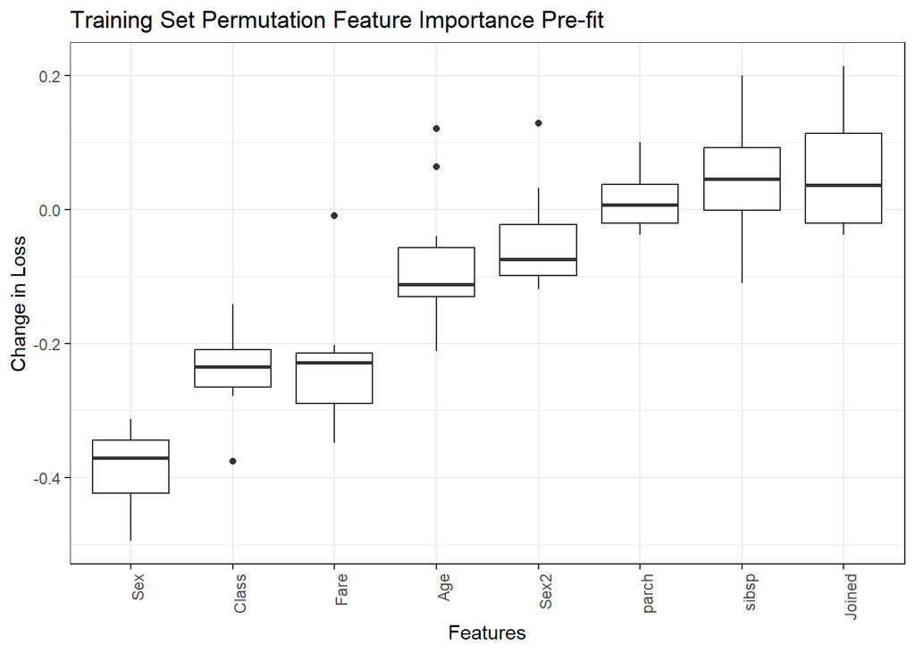

```r
permute_fit <- function(train_data, test_data, final_workflow, col, M = 10) {
  losses <- numeric(M)

  for (i in 1:M) {
    permuted_train <- train_data %>%
      mutate(!!col := sample(!!sym(col)))

    permuted_fit <- final_workflow %>% fit(data = permuted_train)


    permuted_preds <- predict(permuted_fit, test_data, type = "prob") %>%
      bind_cols(test_data)

    permuted_loss <- permuted_preds %>%
      mn_log_loss(truth = Survived, .pred_1) %>%
      pull(.estimate)

    losses[i] <- permuted_loss
  }

  return(losses)
}

final_fit <- final_workflow %>% fit(data = titanic_train)
baseline_preds <- predict(final_fit, titanic_test, type = "prob") %>% bind_cols(titanic_test)
baseline_loss <- baseline_preds %>%
  mn_log_loss(truth = Survived, .pred_1) %>%
  pull(.estimate)

set.seed(666)
specified_predictors <- c("Class", "Sex", "Sex2", "Age", "Fare", "sibsp", "parch", "Joined")
feature_importance <- list()

for (col in specified_predictors) {
  losses <- permute_fit(titanic_train, titanic_test, final_workflow, col, M = 10)
  feature_importance[[col]] <- losses - baseline_loss
}

vi_df <- do.call(rbind, lapply(names(feature_importance), function(x) {
  data.frame(Variable = x, ChangeInLoss = feature_importance[[x]])
})) %>%
  as_tibble()

ggplot(vi_df, aes(x = reorder(Variable, ChangeInLoss), y = ChangeInLoss)) +
  geom_boxplot() +
  labs(title = "Training Set Permutation Feature Importance Pre-fit",
       x = "Features",
       y = "Change in Loss") +
  theme(axis.text.x = element_text(angle = 90, hjust = 1))
```

## e. Understanding

Describe how the addition of the almost duplicated predictor impacted the feature importance results.